# Project UAS SML

Devira Maharani (3338240015)

2026-06-02

## Deskripsi Dataset

Dataset ini berisi data profil akademik dan latar belakang siswa (Student Performance). Data terdiri dari 395 observasi dan memuat 7 variabel utama yaitu age (usia siswa), Medu (pendidikan ibu), Fedu (pendidikan ayah), failures (jumlah kegagalan kelas di masa lalu), absences (jumlah hari ketidakhadiran), G3 (nilai ujian akhir siswa), dan Cluster (label kelompok hasil pemodelan clustering).

## Package yang digunakan dan Import Data

Pada tahap awal analisis, digunakan beberapa package di R untuk mendukung proses pengolahan data dan clustering.dilakukan Principal Component Analysis (PCA) menggunakan fungsi prcomp() untuk mereduksi dimensi data dan memudahkan visualisasi hasil clustering.

```r
library(readxl)       # Berfungsi untuk membaca data dari file Excel
```

```r
library(ggplot2)      # Berfungsi untuk membuat grafik dan visualisasi data
library(factoextra)   # Berfungsi untuk mempermudah visualisasi hasil analisis multivariat
library(dbscan)       # Berfungsi untuk menjalankan algoritma clustering berbasis kerapatan dan mencari nilai epsilon optimal
library(mclust)       # Berfungsi untuk memodelkan clustering berbasis distribusi parametrik
library(cluster)      # Berfungsi untuk menghitung metrik evaluasi jarak dan validasi internal klaster
library(fpc)          # Berfungsi untuk komputasi klaster fleksibel dan menyediakan statistik perbandingan karakteristik model
# Import Data Excel
data_tugas <- read_excel("~/Devira sem 4/SML/DATA TUGAS SML CLUTERING.xlsx")

# Pilih variabel numerik dan standarisasi
data_scaling <- scale(data_tugas[, c("age", "Medu", "Fedu", "failures", "absences", "G3")])

# Hitung Proyeksi PCA
pca_output <- prcomp(data_scaling, scale. = FALSE)
df_pca <- as.data.frame(pca_output$x[, 1:2])
colnames(df_pca) <- c("PC1", "PC2")

#  Menghitung persentase kontribusi varians dari setiap Principal Component (PC)
var_persen <- (pca_output$sdev^2) / sum(pca_output$sdev^2) * 100
```

## Visualisasi Geometri

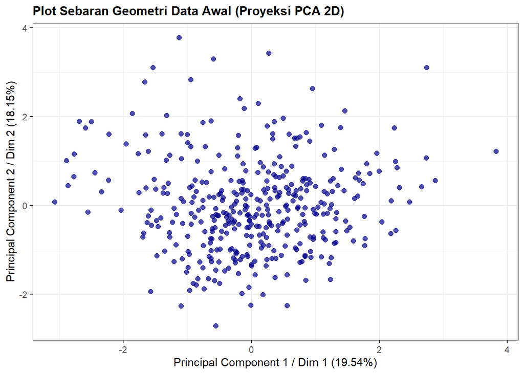

```r
# Visualisasi Geometri Data Awal dengan Label persentase varians
ggplot(df_pca, aes(x = PC1, y = PC2)) +
  geom_point(col = "darkblue", alpha = 0.7, size = 2) +
  theme_bw() +
  labs(
    title = "Plot Sebaran Geometri Data Awal (Proyeksi PCA 2D)",
    # sprintf("%.2f", ...) memformat angka agar rapi menjadi 2 digit di belakang koma
    x = paste0("Principal Component 1 / Dim 1 (", sprintf("%.2f", var_persen[1]), "%)"),
    y = paste0("Principal Component 2 / Dim 2 (", sprintf("%.2f", var_persen[2]), "%)")
  ) +
  theme(
    plot.title = element_text(face = "bold", size = 12)
)
```

**Interpretasi** Hasil analisis komponen utama (Principal Component Analysis - PCA) dalam bentuk dua dimensi ($2\text{D}$) untuk melihat sebaran geometri dari data awal. Berdasarkan visualisasinya, sumbu horizontal atau komponen utama pertama (PC1) mampu menjelaskan 19.54% varians data, sedangkan sumbu vertikal atau komponen utama kedua (PC2) menjelaskan 18.15% varians data. Secara akumulatif, kedua dimensi ini hanya mampu merangkum sekitar 37.69% dari total informasi atau keragaman yang ada pada data asli.Dari pola sebarannya, titik-titik data terlihat menumpuk dengan sangat padat di area pusat, yaitu di sekitar koordinat (0,0). Pola memusat ini menunjukkan bahwa mayoritas objek data memiliki karakteristik atau nilai fitur yang relatif serupa dan homogen pada ruang reduksi ini. Selain itu, tidak terlihat adanya pemisahan kelompok (clustering) yang jelas atau kontras di antara titik-titik data tersebut.

## Distance-Based Clustering (DBSCAN)

Pada tahap clustering, digunakan algoritma Density-Based Spatial Clustering of Applications with Noise (DBSCAN) untuk mengelompokkan data berdasarkan tingkat kepadatan (density) tanpa perlu menentukan jumlah klaster di awal.

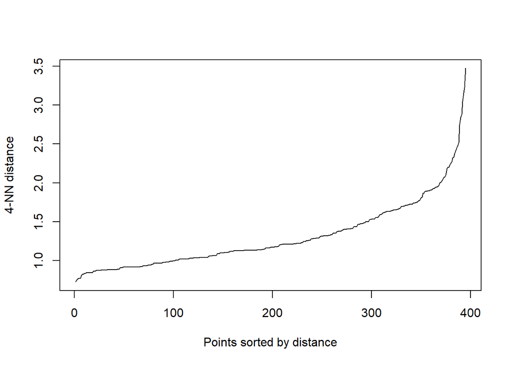

```r
# DBSCAN
set.seed(123)

# Menentukan Nilai Epsilon Optimal (K-NN Distance Plot)
kNNdistplot(data_scaling, k = 4)
```

```r
# Menjalankan DBSCAN
res_dbscan <- dbscan::dbscan(data_scaling, eps = 1.4, minPts = 4)
table(res_dbscan$cluster)
```

```
##
##   0   1   2   3   4
##  61 321   5   4   4
```

## Spectral Clustering

Pada tahap Spectral Clustering untuk mengelompokkan data berdasarkan struktur kemiripan antar observasi. Proses diawali dengan menghitung matriks kemiripan (similarity matrix) menggunakan Gaussian Kernel, yang mengubah jarak antar data menjadi ukuran kemiripan.

```r
# SPECTRAL CLUSTERING
set.seed(123)

# Menghitung matriks kemiripan (Similarity Matrix) berbasis Gaussian Kernel
matriks_kemiripan <- exp(-as.matrix(dist(data_scaling))^2)

# Proses Dekomposisi Nilai Eigen
hasil_eigen <- eigen(matriks_kemiripan)

# Ekstraksi 4 eigenvector terbesar/terkecil (Menyesuaikan jumlah kluster target)
jumlah_kluster <- 4
vektor_eigen_terpilih <- hasil_eigen$vectors[, 1:jumlah_kluster]

# Implementasi K-Means pada baris eigenvector yang sudah dipilih
model_spectral <- kmeans(vektor_eigen_terpilih, centers = jumlah_kluster, nstart = 25)

# Menampilkan tabel distribusi jumlah data per kluster
table(model_spectral$cluster)
```

```
##
##   1   2   3   4
##  46  29  43 277
```

```r
# Memasukkan label klaster terbaik ke dataframe PCA
df_pca$Cluster_Terpilih <- as.factor(model_spectral$cluster) # Menggunakan model_spectral milikmu
```

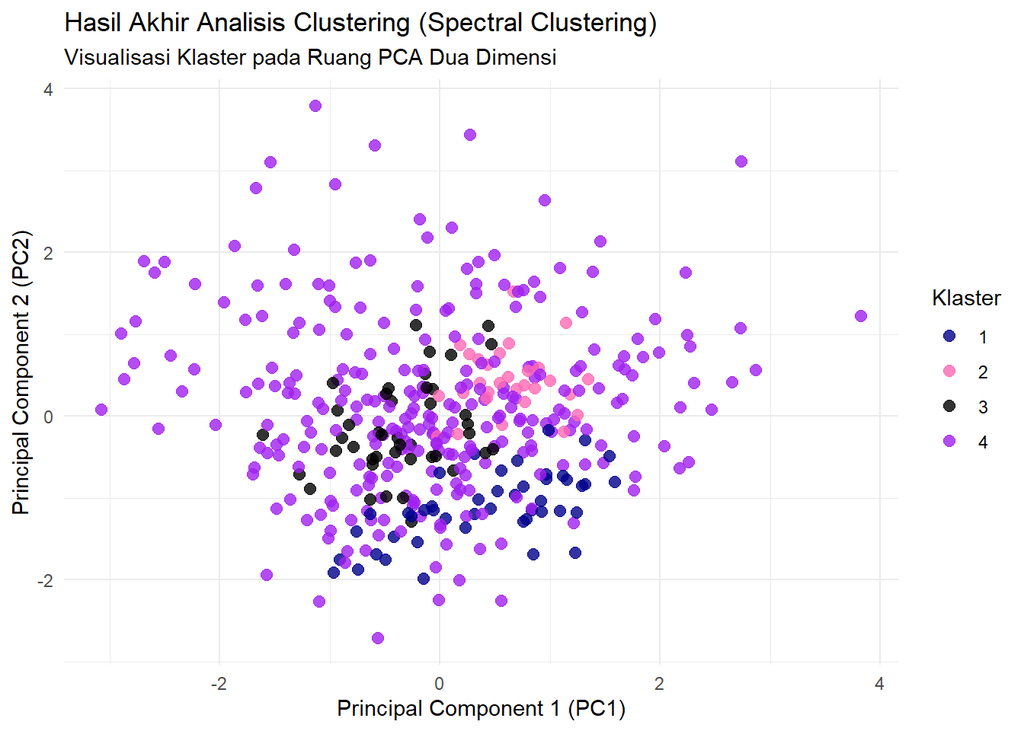

```r
# Visualisasi plot klaster hasil Spectral Clustering
ggplot(df_pca, aes(x = PC1, y = PC2, col = Cluster_Terpilih)) +
  geom_point(alpha = 0.8, size = 2.5) +
  # Kode warna langsung dimasukkan ke dalam fungsi di bawah ini:
  scale_color_manual(values = c("darkblue", "hotpink", "black", "purple")) +
  theme_minimal() +
  labs(
    title = "Hasil Akhir Analisis Clustering (Spectral Clustering)",
    subtitle = "Visualisasi Klaster pada Ruang PCA Dua Dimensi",
    x = "Principal Component 1 (PC1)",
    y = "Principal Component 2 (PC2)",
    col = "Klaster"
  )
```

**Interpretasi** Visualisasi pada ruang komponen utama dua dimensi (PC1 dan PC2) menunjukkan bagaimana data multidimensi asli berhasil direduksi untuk memperlihatkan struktur pengelompokan yang dihasilkan oleh metode Spectral Clustering. Berdasarkan sebaran titik data, terbentuk empat klaster yang memiliki karakteristik kepadatan dan cakupan wilayah yang sangat berbeda di dalam ruang komponen utama ini. Klaster 1 tampak mengelompok cukup rapat di area bawah, didominasi oleh nilai PC2 negatif pada rentang 0 hingga -2. Sementara itu, Klaster 2 dan Klaster 3 menunjukkan tingkat homogenitas atau kemiripan objek yang sangat tinggi. Hal ini terlihat dari kerapatan titik-titiknya yang berpusat di area tengah, di mana Klaster 2 condong ke arah kanan (PC1 positif) dan Klaster 3 cenderung berada di area tengah agak kiri (PC1 negatif).

## Model-Based Clustering (Gaussian Mixture Model / GMM)

Pada tahap ini dilakukan Model-Based Clustering menggunakan metode Gaussian Mixture Model (GMM) melalui fungsi Mclust(). Metode ini mengasumsikan bahwa data berasal dari campuran beberapa distribusi Gaussian (normal), di mana setiap distribusi merepresentasikan satu klaster. Berbeda dengan metode clustering berbasis jarak, GMM mengelompokkan data berdasarkan probabilitas keanggotaan pada setiap klaster.

```r
# model based GMM
# Membuat model GMM
gmm_model <- Mclust(data_scaling)

# Menampilkan ringkasan hasil model
summary(gmm_model)
```

```
## ----------------------------------------------------
## Gaussian finite mixture model fitted by EM algorithm
## ----------------------------------------------------
##
## Mclust EEV (ellipsoidal, equal volume and shape) model with 5 components:
##
##  log-likelihood   n  df       BIC       ICL
##       -2554.732 395 115 -5797.037 -5883.342
##
## Clustering table:
##   1   2   3   4   5
##  28  10 103  39 215
```

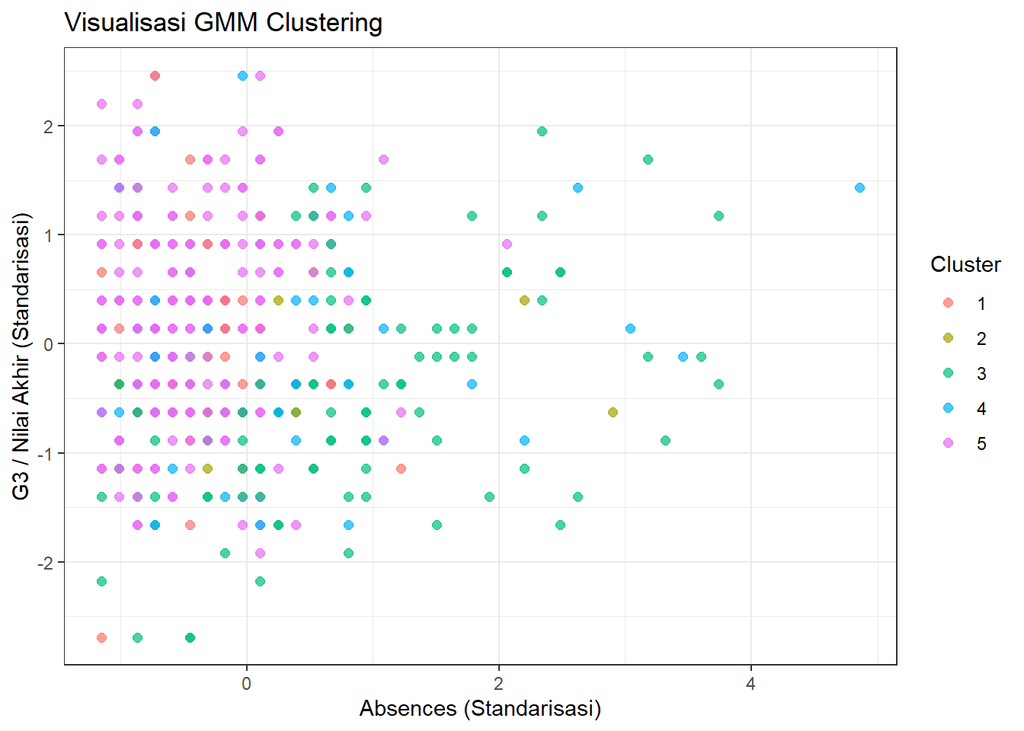

```r
# Visualisasi
cluster_assigment <- predict(gmm_model)$classification

# Ubah data_scaling menjadi data frame agar bisa dibaca oleh ggplot
data_plot <- as.data.frame(data_scaling)

# Tambahkan kolom cluster ke dalam data frame tersebut
data_plot$Cluster <- as.factor(cluster_assigment)

#Gambar plot dengan variabel yang benar (x = absences, y = G3)
ggplot(data = data_plot, aes(x = absences, y = G3)) +
  geom_point(aes(col = Cluster), alpha = 0.7, size = 2) +
  theme_bw() +
  labs(
    title = "Visualisasi GMM Clustering",
    x = "Absences (Standarisasi)",
    y = "G3 / Nilai Akhir (Standarisasi)",
    col = "Cluster"
  )
```

## Clustering Criteria

Pada tahap ini dilakukan evaluasi kualitas klaster untuk membandingkan performa metode DBSCAN, Spectral Clustering, dan Gaussian Mixture Model (GMM) menggunakan Silhouette Coefficient.

```r
# Hitung matriks jarak antar objek dari data yang discaling
dist_data <- dist(data_scaling)

# Ambil penugasan klaster dari ketiga model
fit_dbscan <- res_dbscan$cluster
fit_spectral <- model_spectral$cluster
fit_gmm <- cluster_assigment

# Hitung rata-rata Silhouette Width untuk masing-masing model
# (Catatan: Untuk DBSCAN, noise/cluster 0 diabaikan agar tidak merusak interpretasi)
sil_dbscan <- mean(silhouette(fit_dbscan[fit_dbscan > 0], dist(data_scaling[fit_dbscan > 0, ]))[, 3])
sil_spectral <- mean(silhouette(fit_spectral, dist_data)[, 3])
sil_gmm <- mean(silhouette(fit_gmm, dist_data)[, 3])

# Tampilkan hasil komparasi untuk menentukan model terbaik
cat("Nilai mendekati 1 berarti struktur klaster semakin baik/terpisah.\n\n")
```

```
## Nilai mendekati 1 berarti struktur klaster semakin baik/terpisah.
```

```r
cat(" -> Nilai Silhouette DBSCAN   :", round(sil_dbscan, 4), "\n")
```

```
##  -> Nilai Silhouette DBSCAN   : 0.1866
```

```r
cat(" -> Nilai Silhouette Spectral :", round(sil_spectral, 4), "\n")
```

```
##  -> Nilai Silhouette Spectral : -0.0787
```

```r
cat(" -> Nilai Silhouette GMM      :", round(sil_gmm, 4), "\n")
```

```
##  -> Nilai Silhouette GMM      : 0.1139
```

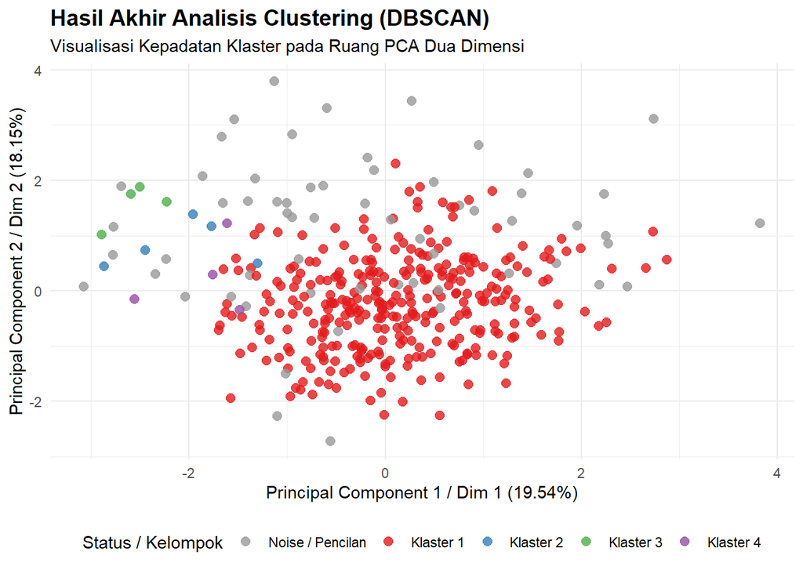

```r
# VISUALISASI HASIL Akhir
# Ekstrak persentase varians dari objek PCA untuk sumbu X dan Y
var_persen <- (pca_output$sdev^2 / sum(pca_output$sdev^2)) * 100
df_pca$Cluster_Terpilih <- fit_dbscan

# Mengubah angka klaster menjadi label teks akademis
df_pca$Cluster_Terpilih <- factor(
  df_pca$Cluster_Terpilih,
  levels = c(0, sort(unique(fit_dbscan[fit_dbscan > 0]))),
  labels = c("Noise / Pencilan", paste("Klaster", sort(unique(fit_dbscan[fit_dbscan > 0]))))
)

# Menyiapkan palet warna kustom (Abu-abu untuk Noise, warna cerah untuk klaster resmi)
jumlah_klaster_resmi <- length(unique(fit_dbscan[fit_dbscan > 0]))
warna_palet <- c("gray60", scales::brewer_pal(palette = "Set1")(jumlah_klaster_resmi))

# Gambar Plot Scatter PCA
plot_pca <- ggplot(df_pca, aes(x = PC1, y = PC2, col = Cluster_Terpilih)) +
  geom_point(alpha = 0.8, size = 2.5) +
  scale_color_manual(values = warna_palet) +
  theme_minimal() +
  labs(
    title = "Hasil Akhir Analisis Clustering (DBSCAN)",
    subtitle = "Visualisasi Kepadatan Klaster pada Ruang PCA Dua Dimensi",
    x = paste0("Principal Component 1 / Dim 1 (", sprintf("%.2f", var_persen[1]), "%)"),
    y = paste0("Principal Component 2 / Dim 2 (", sprintf("%.2f", var_persen[2]), "%)"),
    col = "Status / Kelompok"
  ) +
  theme(
    legend.position = "bottom",
    plot.title = element_text(face = "bold", size = 14)
  )

# Tampilkan Plot PCA
print(plot_pca)
```

**Interpretasi Hasil Akhir** Berdasarkan visualisasi hasil clustering menggunakan metode DBSCAN pada ruang PCA dua dimensi, terlihat bahwa sebagian besar data berhasil dikelompokkan ke dalam Klaster 1 (warna merah). Hal ini menunjukkan bahwa mayoritas observasi memiliki tingkat kemiripan yang tinggi dan membentuk satu kelompok utama yang padat di sekitar pusat distribusi data.Selain itu, terdapat sejumlah titik berwarna abu-abu yang diklasifikasikan sebagai noise atau pencilan (outlier). Titik-titik ini tidak memiliki kepadatan tetangga yang cukup untuk dimasukkan ke dalam suatu klaster berdasarkan parameter DBSCAN yang digunakan. Keberadaan noise menunjukkan adanya observasi yang memiliki pola berbeda atau menyimpang dari kelompok data utama.Secara keseluruhan, hasil clustering mengindikasikan bahwa struktur data didominasi oleh satu kelompok besar dengan beberapa kelompok kecil serta sejumlah pencilan, sehingga pola kepadatan data cenderung terpusat pada Klaster 1 dan menyebar pada area tertentu.